# Wine analytics Notebook

```r
library("ggfortify")
```

Linear model

$$y = \beta_0 + \beta_1 x_1 + \beta_2 x_2 + \beta_3 x_3 + \epsilon$$
Find the set of $\beta$ such that $\epsilon$ is minimum.

The dataset consists of 38 observations of 6 variables (small dataset): 1952 to 1989. Ashenfelter published his paper in 1990.

```r
summary(wine)
```

```
      VINT          LPRICE           WRAIN          DEGREES          HRAIN          TIME_SV
 Min.   :1952   Min.   :-2.289   Min.   :376.0   Min.   :14.98   Min.   : 38.0   Min.   :-6.00
 1st Qu.:1961   1st Qu.:-1.985   1st Qu.:510.2   1st Qu.:16.18   1st Qu.: 87.5   1st Qu.: 3.25
 Median :1970   Median :-1.509   Median :586.5   Median :16.54   Median :120.5   Median :12.50
 Mean   :1970   Mean   :-1.452   Mean   :605.0   Mean   :16.57   Mean   :137.0   Mean   :12.50
 3rd Qu.:1980   3rd Qu.:-1.052   3rd Qu.:713.5   3rd Qu.:17.09   3rd Qu.:171.0   3rd Qu.:21.75
 Max.   :1989   Max.   : 0.000   Max.   :845.0   Max.   :18.50   Max.   :292.0   Max.   :31.00
                NA's   :11
```

1954 and 1956 wine prices are not available in the dataset since they are rarely sold now. The prices from 1981 to 1989 are not available in the dataset.

```r
is.na(wine)
```

```
       VINT LPRICE WRAIN DEGREES HRAIN TIME_SV
 [1,] FALSE  FALSE FALSE   FALSE FALSE   FALSE
 [2,] FALSE  FALSE FALSE   FALSE FALSE   FALSE
 [3,] FALSE   TRUE FALSE   FALSE FALSE   FALSE
 [4,] FALSE  FALSE FALSE   FALSE FALSE   FALSE
 [5,] FALSE   TRUE FALSE   FALSE FALSE   FALSE
 [6,] FALSE  FALSE FALSE   FALSE FALSE   FALSE
 [7,] FALSE  FALSE FALSE   FALSE FALSE   FALSE
 [8,] FALSE  FALSE FALSE   FALSE FALSE   FALSE
 [9,] FALSE  FALSE FALSE   FALSE FALSE   FALSE
[10,] FALSE  FALSE FALSE   FALSE FALSE   FALSE
[11,] FALSE  FALSE FALSE   FALSE FALSE   FALSE
[12,] FALSE  FALSE FALSE   FALSE FALSE   FALSE
[13,] FALSE  FALSE FALSE   FALSE FALSE   FALSE
[14,] FALSE  FALSE FALSE   FALSE FALSE   FALSE
```

[output cut: 24 more lines]

The scatter plot indicates a negative relationship but there is considerable variation that still needs to be captured. We can also plot a matrix of all scatter plots using the pairs command. Use plot() or ggplot() pairs.panels() or pairs()

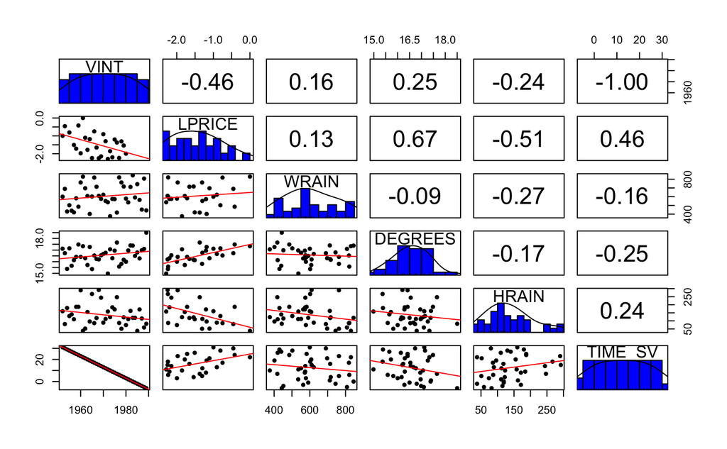

[figure not shown]

Split the data set into a training dataset from 1952 to 1978 (drop 1954 and 1956 since prices are not observable) and we use the test set from 1979 onwards. Note that for the test set however we only have prices till 1980 (so in this case we can only use 1979 and 1980) to test the model.

|  | VINT | LPRICE | WRAIN | DEGREES | HRAIN | TIME_SV |
| --- | --- | --- | --- | --- | --- | --- |
| 28 | 1979 | -1.53960 | 717 | 16.1667 | 122 | 4 |
| 29 | 1980 | -1.99582 | 578 | 16.0000 | 74 | 3 |
| 30 | 1981 | NA | 535 | 16.9667 | 111 | 2 |
| 31 | 1982 | NA | 712 | 17.4000 | 162 | 1 |
| 32 | 1983 | NA | 845 | 17.3833 | 119 | 0 |
| 33 | 1984 | NA | 591 | 16.5000 | 119 | -1 |
| 34 | 1985 | NA | 744 | 16.8000 | 38 | -2 |
| 35 | 1986 | NA | 563 | 16.2833 | 171 | -3 |
| 36 | 1987 | NA | 452 | 16.9833 | 115 | -4 |
| 37 | 1988 | NA | 808 | 17.1000 | 59 | -5 |

[output cut: 1 more lines]

One variable regression - lm() is the basic command to fit a linear model to the data.

```r
summary(model1)
```

```
Call:
lm(formula = LPRICE ~ VINT, data = winetrain)

Residuals:
     Min       1Q   Median       3Q      Max
-0.84574 -0.46266 -0.09462  0.48752  1.24478

Coefficients:
            Estimate Std. Error t value Pr(>|t|)
(Intercept) 72.99301   30.98789   2.356   0.0274 *
VINT        -0.03786    0.01576  -2.402   0.0248 *
---
Signif. codes:  0 ‘***’ 0.001 ‘**’ 0.01 ‘*’ 0.05 ‘.’ 0.1 ‘ ’ 1

Residual standard error: 0.594 on 23 degrees of freedom
Multiple R-squared:  0.2005,    Adjusted R-squared:  0.1657
F-statistic: 5.768 on 1 and 23 DF,  p-value: 0.0248
```

```r
ggplot(...)
```

[output not shown]

```r
summary(model1)
```

```
Call:
lm(formula = LPRICE ~ VINT, data = winetrain)

Residuals:
     Min       1Q   Median       3Q      Max
-0.84574 -0.46266 -0.09462  0.48752  1.24478

Coefficients:
            Estimate Std. Error t value Pr(>|t|)
(Intercept) 72.99301   30.98789   2.356   0.0274 *
VINT        -0.03786    0.01576  -2.402   0.0248 *
---
Signif. codes:  0 ‘***’ 0.001 ‘**’ 0.01 ‘*’ 0.05 ‘.’ 0.1 ‘ ’ 1

Residual standard error: 0.594 on 23 degrees of freedom
Multiple R-squared:  0.2005,    Adjusted R-squared:  0.1657
F-statistic: 5.768 on 1 and 23 DF,  p-value: 0.0248
```

The result indicates that older the wine, greater is the value but there is still significant variation.

One variable regression - continued

```r
summary(model2)
```

```
Call:
lm(formula = LPRICE ~ WRAIN, data = winetrain)

Residuals:
     Min       1Q   Median       3Q      Max
-0.95348 -0.65439  0.04172  0.43136  1.27550

Coefficients:
              Estimate Std. Error t value Pr(>|t|)
(Intercept) -1.8331730  0.6286160  -2.916  0.00777 **
WRAIN        0.0006719  0.0010155   0.662  0.51479
---
Signif. codes:  0 ‘***’ 0.001 ‘**’ 0.01 ‘*’ 0.05 ‘.’ 0.1 ‘ ’ 1

Residual standard error: 0.6581 on 23 degrees of freedom
Multiple R-squared:  0.01868,   Adjusted R-squared:  -0.02399
F-statistic: 0.4377 on 1 and 23 DF,  p-value: 0.5148
```

```r
summary(model3)
```

```
Call:
lm(formula = LPRICE ~ HRAIN, data = winetrain)

Residuals:
    Min      1Q  Median      3Q     Max
-1.1116 -0.3228 -0.1008  0.3691  1.1977

Coefficients:
             Estimate Std. Error t value Pr(>|t|)
(Intercept) -0.695162   0.249152   -2.79  0.01040 *
HRAIN       -0.004923   0.001506   -3.27  0.00337 **
---
Signif. codes:  0 ‘***’ 0.001 ‘**’ 0.01 ‘*’ 0.05 ‘.’ 0.1 ‘ ’ 1

Residual standard error: 0.5489 on 23 degrees of freedom
Multiple R-squared:  0.3173,    Adjusted R-squared:  0.2877
F-statistic: 10.69 on 1 and 23 DF,  p-value: 0.003366
```

```r
summary(model4)
```

```
Call:
lm(formula = LPRICE ~ DEGREES, data = winetrain)

Residuals:
     Min       1Q   Median       3Q      Max
-0.78449 -0.23885 -0.03727  0.38994  0.90320

Coefficients:
            Estimate Std. Error t value Pr(>|t|)
(Intercept) -11.9114     2.4935  -4.777 8.12e-05 ***
DEGREES       0.6351     0.1509   4.208 0.000335 ***
---
Signif. codes:  0 ‘***’ 0.001 ‘**’ 0.01 ‘*’ 0.05 ‘.’ 0.1 ‘ ’ 1

Residual standard error: 0.4993 on 23 degrees of freedom
Multiple R-squared:  0.435, Adjusted R-squared:  0.4105
F-statistic: 17.71 on 1 and 23 DF,  p-value: 0.0003351
```

Two variables - The effect of DEGREES and HRAIN on LPRICE.

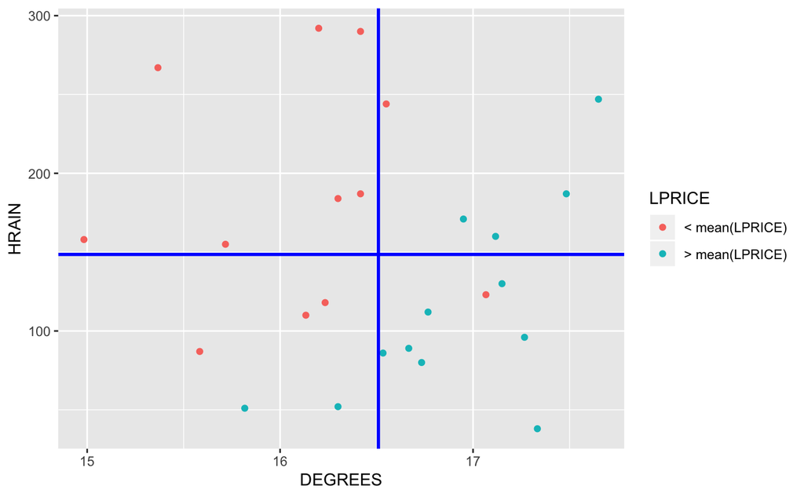

The figure indicates that hot and dry summers produce wines that obtain higher prices while cooler summers with more rain gives lower priced wines. 1961 is an year where an extremely high quality wine was produced.

Two variable regression

```r
summary(model5)
```

```
Call:
lm(formula = LPRICE ~ DEGREES + HRAIN, data = winetrain)

Residuals:
     Min       1Q   Median       3Q      Max
-0.88319 -0.19599  0.06181  0.15379  0.59724

Coefficients:
             Estimate Std. Error t value Pr(>|t|)
(Intercept) -10.69628    1.85444  -5.768 8.40e-06 ***
DEGREES       0.60261    0.11128   5.415 1.94e-05 ***
HRAIN        -0.00457    0.00101  -4.525 0.000167 ***
---
Signif. codes:  0 ‘***’ 0.001 ‘**’ 0.01 ‘*’ 0.05 ‘.’ 0.1 ‘ ’ 1

Residual standard error: 0.3674 on 22 degrees of freedom
Multiple R-squared:  0.7074,    Adjusted R-squared:  0.6808
F-statistic: 26.59 on 2 and 22 DF,  p-value: 1.348e-06
```

LPRICE = -10.69 + 0.602*DEGREES - 0.0045*HRAIN. Both variables are extremely significant in the fit with R^2 = 0.7 and adjusted R^2 = 0.68.

Multiple linear regression

```r
summary(model6)
```

```
Call:
lm(formula = LPRICE ~ VINT + TIME_SV, data = winetrain)

Residuals:
     Min       1Q   Median       3Q      Max
-0.84574 -0.46266 -0.09462  0.48752  1.24478

Coefficients: (1 not defined because of singularities)
            Estimate Std. Error t value Pr(>|t|)
(Intercept) 72.99301   30.98789   2.356   0.0274 *
VINT        -0.03786    0.01576  -2.402   0.0248 *
TIME_SV           NA         NA      NA       NA
---
Signif. codes:  0 ‘***’ 0.001 ‘**’ 0.01 ‘*’ 0.05 ‘.’ 0.1 ‘ ’ 1

Residual standard error: 0.594 on 23 degrees of freedom
Multiple R-squared:  0.2005,    Adjusted R-squared:  0.1657
F-statistic: 5.768 on 1 and 23 DF,  p-value: 0.0248
```

Note tha TIME_SV coefficients are not defined as it is perfectly correlated with the VINT variable (perfect multicollinearity). We drop the variable and redo the regression. High correlation (in absolute value) between independent variables is not good (indication of multicollinearity) while high correlation (in absolute value) between dependent and independent variables is good.

```r
summary(model7)
```

```
Call:
lm(formula = LPRICE ~ VINT + DEGREES + HRAIN + WRAIN, data = winetrain)

Residuals:
     Min       1Q   Median       3Q      Max
-0.45473 -0.24276  0.00753  0.19770  0.53640

Coefficients:
              Estimate Std. Error t value Pr(>|t|)
(Intercept) 35.5297567 16.4435924   2.161 0.043028 *
VINT        -0.0239302  0.0080969  -2.955 0.007821 **
DEGREES      0.6072099  0.0987030   6.152  5.2e-06 ***
HRAIN       -0.0039715  0.0008538  -4.652 0.000154 ***
WRAIN        0.0010756  0.0005073   2.120 0.046684 *
---
Signif. codes:  0 ‘***’ 0.001 ‘**’ 0.01 ‘*’ 0.05 ‘.’ 0.1 ‘ ’ 1

Residual standard error: 0.295 on 20 degrees of freedom
Multiple R-squared:  0.8286,    Adjusted R-squared:  0.7943
F-statistic: 24.17 on 4 and 20 DF,  p-value: 2.036e-07
```

R^2 = 0.828 and adjusted R^2 = 0.794. The coefficients indicate that high quality wines correlate strongly in a positive manner with summer temperatures, negatively correlate with harvest rain and positively correlate with winter rain. The result indicates that 80% of the variaion can be explained by including the weather variables in comparison to 20% with only the vintage year.

```r
summary(model7a)
```

```
Call:
lm(formula = LPRICE ~ WRAIN + DEGREES + HRAIN, data = winetrain)

Residuals:
     Min       1Q   Median       3Q      Max
-0.67475 -0.12957  0.01975  0.20754  0.63848

Coefficients:
              Estimate Std. Error t value Pr(>|t|)
(Intercept) -1.280e+01  2.037e+00  -6.282 3.13e-06 ***
WRAIN        1.177e-03  5.920e-04   1.987 0.060085 .
DEGREES      6.810e-01  1.117e-01   6.097 4.75e-06 ***
HRAIN       -3.948e-03  9.987e-04  -3.953 0.000726 ***
---
Signif. codes:  0 ‘***’ 0.001 ‘**’ 0.01 ‘*’ 0.05 ‘.’ 0.1 ‘ ’ 1

Residual standard error: 0.345 on 21 degrees of freedom
Multiple R-squared:  0.7537,    Adjusted R-squared:  0.7185
F-statistic: 21.42 on 3 and 21 DF,  p-value: 1.359e-06
```

We can run the model by dropping VINT but this decreases R^2 to 0.75 and adjusted R^2 to 0.71.

We can obtain confidence intervals for the estimates using the confint command.

```r
confint(model7,level=0.99)
```

```
                    0.5 %        99.5 %
(Intercept) -1.125785e+01 82.3173631200
VINT        -4.696870e-02 -0.0008916014
DEGREES      3.263662e-01  0.8880534986
HRAIN       -6.400860e-03 -0.0015421290
WRAIN       -3.678252e-04  0.0025189572
```

```r
1-sse5/sst
```

```
[1] -0.08201462
```

We use the training test mean to compute the total sum of squares for computing the test R^2 values. The results indicate that better R^2 in the training set does not necessarily indicate better R^2 in test set (this can also be negative).

```r
ggplot(wine,aes(LPRICE))+geom_histogram(...)
#hist(wine$LPRICE)
#hist(exp(wine$LPRICE))
```

[output not shown]

The use of logarithms for prices is fairly common in the economics literature - partly jusified by skewed values in some datasets dealing with numbers such as salaries and partly justified by functional relations such as y = exp(a+bx) which gives log y = a+bx. Such transformations need to be justified and is sometime specific to domains. Even if one directly uses prices in the regression, similar insights are found in this dataset.